# Lecture 2: Simplifying Surface Transport

1. Motivation: the stratigraphic record
   - An example
   - Modeling basin fill
2. What is diffusion?
   - Numerical example
   - Diffusive flux: what is it in *words* and *math*
   - Continuity equation: what is it in *words* and *math*
   - Diffusion as a transport mechanism
3. Assignment 1: diffusive transport

[figure not shown]

*We acknowledge and respect the lək̓ʷəŋən peoples on whose traditional territory the university stands and the Songhees, Esquimalt and W̱SÁNEĆ peoples whose historical relationships with the land continue to this day.*

Po River (Italy)

[figure not shown]

What do you see? Are there any patterns or features that stand out?

Po River (Italy)

Class observations/interpretations

- topsets (flat lying reflectors behind foresets) seem to indicate local sea level rise
- foresets prograde (move into the basin) and maybe increase a little bit in elevation

[figure not shown]

## Simulating basin fill

*Forward* models can be used to explore some of these complex interactions. Generally there are two types of numerical models:

- complex fluid-flow models [(think about the complexity of coastal dynamics)](https://earthengine.google.com/timelapse#v=23.47002,-75.69627,11.322,latLng&t=0.45&ps=50&bt=19840101&et=20181231&startDwell=0&endDwell=0)
  - use very real physical equations to simulate movement in 3-D of each grain
  - need accurate and high resolution data
  - computationally expensive
  - challenging to learn from or compare to stratigraphic data
- empirical transport models
  - approximate transport laws combined with conservation equations (**diffusion**)
  - does not mimic in detail each geologic process
  - computationally inexpensive
  - model outputs can be easily compared to real data

# What is diffusion?

Lets take a look at some examples of diffusion..

A working definition of diffusion: *is the net movement of anything (for example, atom, sediments, energy) from a region of higher concentration to a region of lower concentration*.

[figure not shown]

Note that it is the complex interaction of particles above that causes diffusion, not some inherent desire to randomly move.

In Chemistry, Diffusion describes the process where **entropy** is increased as concentration gradients (chemical potential) are erased. How might diffusion be useful to describing sedimentary transport?

Diffusion is a good predictor of the **net effect** many transport related processes such as tidal currents, storms, bioturbation, the growth and death of reefs, etc.

- acts to decrease topographic gradients (gravitational potential energy)
- useful for building intuition about the stratigraphic record

The key here is that we can estimate the net change without understanding the details of every interaction.

## Numerical example

If diffusion is the result of complex interactions, we can simulate those processes with random motion, and explore the system with a simple script. First, let's create a 2D world of 0's and 1's and introduce random motion.

Import some tools

```python
import numpy as np
from matplotlib import pyplot as plt
from tqdm.notebook import tqdm
import seaborn as sns
sns.set_context('talk')
%matplotlib inline
```

```python
row=[True]*10+[False]*10
row=[row]*1000
row=np.array(row)
print(row)
new_row = np.copy(row)
```

```
[[ True  True  True ... False False False]
 [ True  True  True ... False False False]
 [ True  True  True ... False False False]
 ...
 [ True  True  True ... False False False]
 [ True  True  True ... False False False]
 [ True  True  True ... False False False]]
```

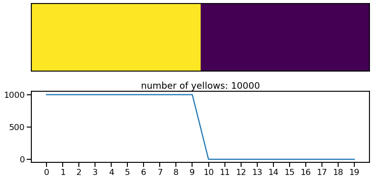

```python
fig=plt.figure(figsize=(12,6))
plt.subplot(2,1,1)
plt.imshow(row,interpolation='nearest')
plt.gca().set_aspect(1/250)
plt.gca().set_xticks([])
plt.gca().set_yticks([])
plt.subplot(2,1,2)
plt.plot(np.arange(20),np.sum(row,axis=0))
plt.gca().set_xticks(np.arange(20))
plt.gca().set_title('number of yellows: %2.0f' % (np.sum(row)))
plt.gca().set_aspect(1/250)
```

Introduce *random* motion

```python
for n in range(10):
    row=np.copy(new_row)
    for i in range(1,1000-1):
        for j in range(1,20-1):
            change_x = np.random.choice([-1,0,1])
            change_y = np.random.choice([-1,0,1])
            new_row[i,j] = row[i+change_x,j+change_y]
```

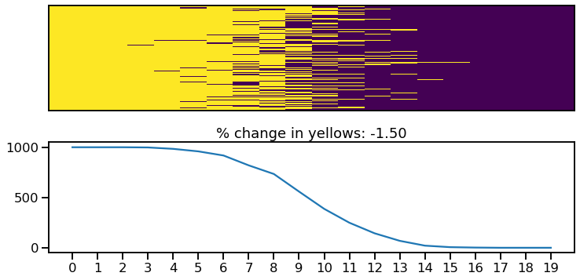

```python
def make_fig(row,show_grad=False):
    fig=plt.figure(figsize=(12,6))
    plt.subplot(2,1,1)
    plt.imshow(row,interpolation='nearest')
    plt.gca().set_aspect(1/250)
    plt.gca().set_xticks([])
    plt.gca().set_yticks([])
    plt.subplot(2,1,2)
    plt.plot(np.arange(20),np.sum(row,axis=0))
    plt.gca().set_xticks(np.arange(20))
    plt.gca().set_title('%% change in yellows: %2.2f' % (100*np.sum(row)/10000-100))
    plt.gca().set_aspect(1/250)
    if show_grad:
        plt.gca().twinx().plot(np.arange(1,21),np.gradient(np.sum(row,axis=0)),color='r',label='gradient')
        plt.gca().legend(loc='best')

make_fig(row)
```

So how do we describe the change in the amount of yellow?

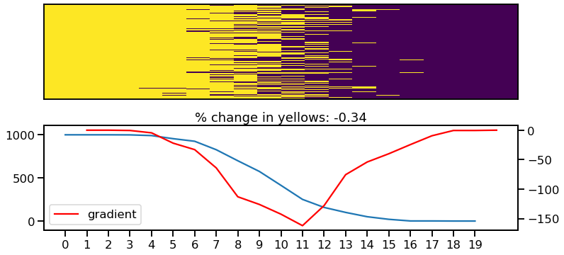

```python
make_fig(row,show_grad=True)
```

where is the diffusive flux largest?

- Flux is largest where the gradient is largest (they are proportional)

## Diffusive flux: what is it in *words*

Lets consider a property, $u$, that is distributed over some spatial grid, $x$. We are interested in what happens to $u$ when we introduce random transport (**diffusion**).

- Diffusion occurs when a (1) conservative property ($u$, like mass, energy, momentum) moves through space (2) at a rate proportional to a gradient

Let's go through **number 2** first:

- [tranportation rate of $u$] is proportional to [ change in amount of $u$ over some distance ]
- [the flux $Q_u$] is proportional to [ the spatial gradient of $u$]

## Diffusive flux: what it is in *math*

The diffusive flux, $Q_u$ is proportional to the spatial gradient of $u$ :

$$\begin{equation} \color{blue}{ Q_u} \propto \color{red}{- \dfrac{\Delta u}{\Delta x}} \end{equation}$$

or introduce a *proportionality constant*, $K$, and now talk about *infinitisimal changes* ($\partial$ vs. $\Delta$):

$$\begin{equation} \color{blue}{Q_u} = \color{red}{- K \dfrac{\partial u}{\partial x}} \end{equation}$$

why is there a negative sign?

## Continuity equation: what is it in *words*

- Diffusion occurs when a (1) conservative property ($u \rightarrow$ like mass, energy, momentum) moves through space (2) at a rate proportional to a gradient
- Now, let's tackle **point number one** (mass balance):
  - [change in $u$ with time] is equal to [ change in transport rate of $u$ with distance ]
  - [rate of change in $u$] is equal to [ the flux gradient of $u$]

## Continuity equation: what is it in *math*

This equality is known as the **continuity equation** (conservation of mass/energy/momentum):
$$\begin{equation} \color{blue}{ \dfrac{\Delta u}{\Delta t}} = \color{red}{- \dfrac{\Delta Q_u}{\Delta x}} = \color{red}{- \dfrac{Q_2 - Q_1}{x_2 - x_1}} \end{equation}$$

Or in proper mathematical terms:
$$\begin{equation} \color{blue}{\dfrac{\partial u}{\partial t}} \color{black}{= } \color{red}{- \dfrac{\partial Q_u}{\partial x}} \end{equation}$$

if Q2 > Q1, then u will:  
if Q2 < Q1, then u will:  
if Q2 = Q1, then u will:

How is this equation a conservation of mass?

By combining these two equations, we can show $u$ will change over time as a function of the second spatial derivative of $u$ (*the curvature*):

| Diffusive flux | Continuity equation |
| --- | --- |
| $Q_u= -K\dfrac{\partial u}{\partial x}$ | $\color{blue}{\dfrac{\partial u}{\partial t}} \color{black}{= } \color{red}{- \dfrac{\partial Q_u}{\partial x}}$ |

$$\begin{equation} \color{blue}{\dfrac{\partial u}{\partial t}} \color{black}{= } K\color{red}{\dfrac{\partial\left(\color{black}{\dfrac{\partial u}{\partial x}}\right)}{\partial x}} \color{black}{= } K \dfrac{\partial^2 u}{\partial x^2}\tag{Diffusion equation} \end{equation}$$

Applying the diffusion equation to a physical system has two general requirements:

1. transport / transfer is proportional to a gradient
2. conservation of mass or energy

## Diffusion as a transport mechanism

When we assume that **diffusive transport** exerts an important control on landscape dynamics we generally accept that particles on the surface of the planet are in constant complex motion, and there is some **downslope bias introduced by gravity** to those motions. Over time, **diffusion** can be assumed to smooth topography (by the transport of material downslope).

$$\begin{equation} \dfrac{\partial h}{\partial t} = K \dfrac{\partial^2 h}{\partial x^2}\tag{hillslope application} \end{equation}$$

**Note: we wouldn't want to use this model to explain transport in rivers, why not?**

# A look ahead

Over the next few weeks in your assignments you will be building a 1-D diffusive transport model to explore how variations in the following properties change the stratigraphic **architecture** of a basin:

1. transport
2. sediment supply
3. accommodation space

# An example: varying accommodation space

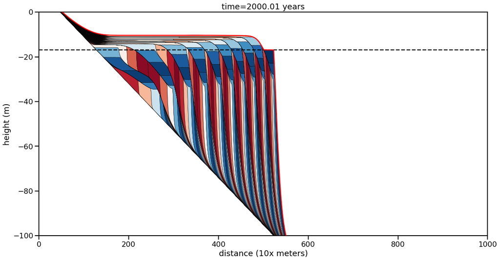

```python
animate_beds(beds=beds,otime=otime,rsl=rsl,aspect=5, ymin=-100)
```

## For next Monday, please come prepared to discuss and work our way through the posted reading (Kenyon and Turcotte, 1985)